# HW2

Author

Chi-Erh Chiu

## Setup

```r
library(tidyverse)
library(nycflights13)
flights <- flights
weather <- weather
planes <- planes
airports <- airports
airlines <- airlines
```

### Question 1

```r
# top 10 most popular destinations
top_10_destinations <- flights %>%
  count(dest, sort = TRUE) %>%
  head(10)
print(top_10_destinations)
```

```
# A tibble: 10 × 2
   dest      n
   <chr> <int>
 1 ORD   17283
 2 ATL   17215
 3 LAX   16174
 4 BOS   15508
 5 MCO   14082
 6 CLT   14064
 7 SFO   13331
 8 FLL   12055
 9 MIA   11728
10 DCA    9705
```

Above table shows the top 10 most popular destinations from NYC in 2013 and the number of flights to each. The most popular destination was ORD with 17,283 flights, followed closely by ATL with 17,215 flights.

### Question 2

```r
# Part 1: Create the new categorical variables
flights_with_time_cats <- flights %>%
  mutate(
    dep_time_cat = case_when(
      dep_time >= 0 & dep_time < 600   ~ "Early Morning",
      dep_time >= 600 & dep_time < 1200  ~ "Morning",
      dep_time >= 1200 & dep_time < 1800 ~ "Afternoon",
      dep_time >= 1800 & dep_time <= 2400~ "Evening",
      TRUE ~ NA_character_
    ),
    arr_time_cat = case_when(
      arr_time >= 0 & arr_time < 600   ~ "Early Morning",
      arr_time >= 600 & arr_time < 1200  ~ "Morning",
      arr_time >= 1200 & arr_time < 1800 ~ "Afternoon",
      arr_time >= 1800 & arr_time <= 2400~ "Evening",
      TRUE ~ NA_character_
    )
  )
time_levels <- c("Early Morning", "Morning", "Afternoon", "Evening")
flights_with_time_cats <- flights_with_time_cats %>%
  mutate(
    dep_time_cat = factor(dep_time_cat, levels = time_levels),
    arr_time_cat = factor(arr_time_cat, levels = time_levels)
  )
```

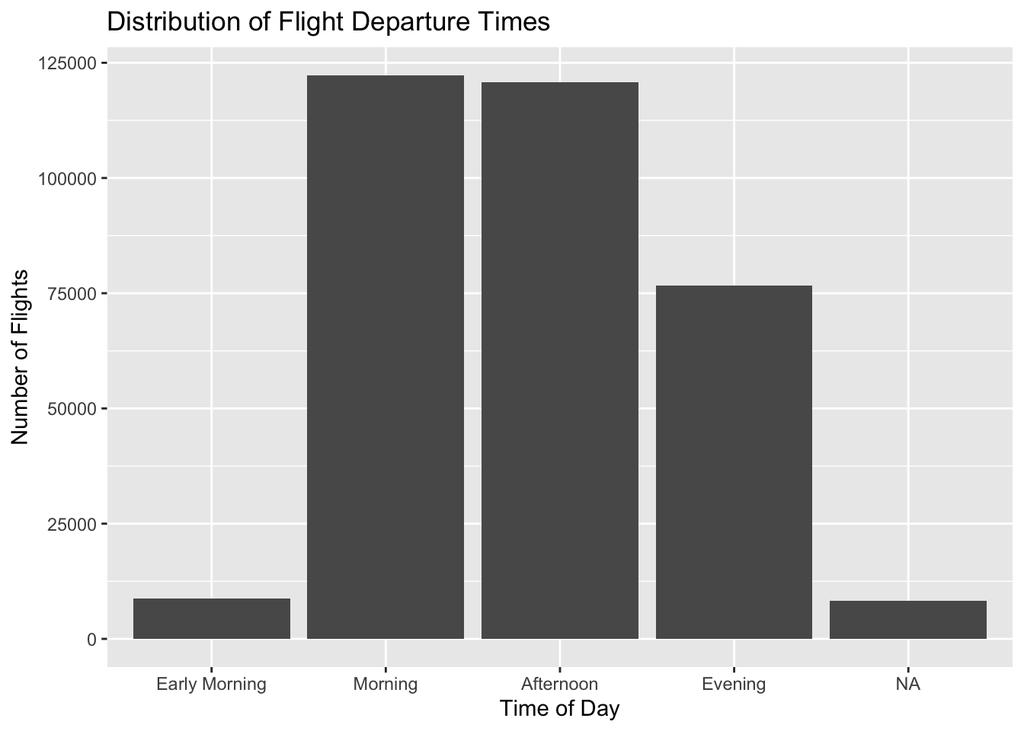

```r
# Part 2: Create barplots
# Plot for departure times
ggplot(data = flights_with_time_cats, aes(x = dep_time_cat)) +
  geom_bar() +
  labs(title = "Distribution of Flight Departure Times",
       x = "Time of Day",
       y = "Number of Flights")
```

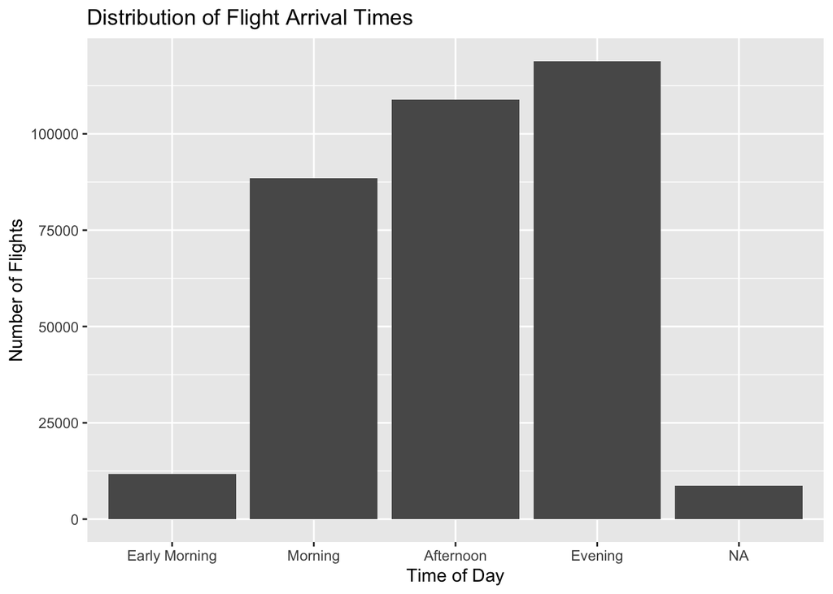

```r
# Plot for arrival times
ggplot(data = flights_with_time_cats, aes(x = arr_time_cat)) +
  geom_bar() +
  labs(title = "Distribution of Flight Arrival Times",
       x = "Time of Day",
       y = "Number of Flights")
```

```r
# Part 3: percentage of "red eye" flights
flights_complete_times <- flights_with_time_cats %>%
  filter(!is.na(dep_time_cat) & !is.na(arr_time_cat))

# number of red eye flights
red_eye_flights <- flights_complete_times %>%
  filter(dep_time_cat %in% c("Afternoon", "Evening") &
         arr_time_cat %in% c("Early Morning", "Morning"))

# Calculate the percentage
red_eye_percentage <- (nrow(red_eye_flights) / nrow(flights_complete_times)) * 100

print(paste("Percentage of red eye flights:", round(red_eye_percentage, 2), "%"))
```

```
[1] "Percentage of red eye flights: 3.24 %"
```

About 3.24 **%** of flights were “red eye” flights

### Question 3

```r
multi_airline_planes <- flights %>%
  filter(!is.na(tailnum)) %>%
  group_by(tailnum) %>%
  summarise(
    distinct_carriers = n_distinct(carrier),
    carriers_list = paste(sort(unique(carrier)), collapse = ", ")
  ) %>%
  filter(distinct_carriers > 1) %>%
  arrange(desc(distinct_carriers))

multi_airline_planes
```

```
# A tibble: 17 × 3
   tailnum distinct_carriers carriers_list
   <chr>               <int> <chr>
 1 N146PQ                  2 9E, EV
 2 N153PQ                  2 9E, EV
 3 N176PQ                  2 9E, EV
 4 N181PQ                  2 9E, EV
 5 N197PQ                  2 9E, EV
 6 N200PQ                  2 9E, EV
 7 N228PQ                  2 9E, EV
 8 N232PQ                  2 9E, EV
 9 N933AT                  2 DL, FL
10 N935AT                  2 DL, FL
11 N977AT                  2 DL, FL
12 N978AT                  2 DL, FL
13 N979AT                  2 DL, FL
14 N981AT                  2 DL, FL
15 N989AT                  2 DL, FL
16 N990AT                  2 DL, FL
17 N994AT                  2 DL, FL
```

Yes, there were 17 planes that flew for multiple airlines. They flew for EV and 9E and others flew for DL and FL.

### Question 4

We see that the “weather” data frame contains hourly weather records for each of the three NYC airports. It has a column named “origin” which contains the FAA airport code (e.g., “JFK”, “LGA”, “EWR”). The “airport” data frame contains detailed information about many airports in the US. It has a column named “faa” which also contains the FAA airport code.

The relationship is that “origin” column in the “weather” data frame corresponds to the “faa” column in the “airports” data frame.In the diagram, this relationship should be shown as a line connecting the “origin” variable in the “weather table to the”faa”variable in the “airports” table. This indicates that we can join these two tables to get more details (like the full name or location) of the airport where the weather was recorded.

### Question 5

```r
weather_duplicates <- weather %>%
  mutate(id = paste(year, month, day, hour, origin, sep = "-")) %>%
  count(id) %>%
  filter(n > 1)
print(weather_duplicates)
```

```
# A tibble: 3 × 2
  id                  n
  <chr>           <int>
1 2013-11-3-1-EWR     2
2 2013-11-3-1-JFK     2
3 2013-11-3-1-LGA     2
```

There are 3 duplicated key values for the key created by combining “origin,”year,” “month,” “day,” and “hour”. The reason for these duplicates could be due to daylight savings times, since 2013-11-3 was when daylight saving times ended.

### Question 6

```r
# merge the flights data and the weather data
flights_weather <- left_join(flights, weather, by = c("time_hour", "origin"))
```

```r
# EDA Step 2: Check the size of the data
dim(flights_weather)
```

```
[1] 336776     32
```

```r
nrow(flights_weather)
```

```
[1] 336776
```

```r
ncol(flights_weather)
```

```
[1] 32
```

```r
# EDA Step 3: Examine the variables and their types
str(flights_weather)
```

```
tibble [336,776 × 32] (S3: tbl_df/tbl/data.frame)
 $ year.x        : int [1:336776] 2013 2013 2013 2013 2013 2013 2013 2013 2013 2013 ...
 $ month.x       : int [1:336776] 1 1 1 1 1 1 1 1 1 1 ...
 $ day.x         : int [1:336776] 1 1 1 1 1 1 1 1 1 1 ...
 $ dep_time      : int [1:336776] 517 533 542 544 554 554 555 557 557 558 ...
 $ sched_dep_time: int [1:336776] 515 529 540 545 600 558 600 600 600 600 ...
 $ dep_delay     : num [1:336776] 2 4 2 -1 -6 -4 -5 -3 -3 -2 ...
 $ arr_time      : int [1:336776] 830 850 923 1004 812 740 913 709 838 753 ...
 $ sched_arr_time: int [1:336776] 819 830 850 1022 837 728 854 723 846 745 ...
 $ arr_delay     : num [1:336776] 11 20 33 -18 -25 12 19 -14 -8 8 ...
 $ carrier       : chr [1:336776] "UA" "UA" "AA" "B6" ...
 $ flight        : int [1:336776] 1545 1714 1141 725 461 1696 507 5708 79 301 ...
 $ tailnum       : chr [1:336776] "N14228" "N24211" "N619AA" "N804JB" ...
 $ origin        : chr [1:336776] "EWR" "LGA" "JFK" "JFK" ...
 $ dest          : chr [1:336776] "IAH" "IAH" "MIA" "BQN" ...
```

[output cut: 18 more lines]

```r
# EDA Step 4 : Look at the top and bottom of the data
# Show the first 6 rows
head(flights_weather)
```

```
# A tibble: 6 × 32
  year.x month.x day.x dep_time sched_dep_time dep_delay arr_time sched_arr_time
   <int>   <int> <int>    <int>          <int>     <dbl>    <int>          <int>
1   2013       1     1      517            515         2      830            819
2   2013       1     1      533            529         4      850            830
3   2013       1     1      542            540         2      923            850
4   2013       1     1      544            545        -1     1004           1022
5   2013       1     1      554            600        -6      812            837
6   2013       1     1      554            558        -4      740            728
# ℹ 24 more variables: arr_delay <dbl>, carrier <chr>, flight <int>,
#   tailnum <chr>, origin <chr>, dest <chr>, air_time <dbl>, distance <dbl>,
#   hour.x <dbl>, minute <dbl>, time_hour <dttm>, year.y <int>, month.y <int>,
#   day.y <int>, hour.y <int>, temp <dbl>, dewp <dbl>, humid <dbl>,
#   wind_dir <dbl>, wind_speed <dbl>, wind_gust <dbl>, precip <dbl>,
#   pressure <dbl>, visib <dbl>
```

```r
# Show the last 6 rows
tail(flights_weather)
```

```
# A tibble: 6 × 32
  year.x month.x day.x dep_time sched_dep_time dep_delay arr_time sched_arr_time
   <int>   <int> <int>    <int>          <int>     <dbl>    <int>          <int>
1   2013       9    30       NA           1842        NA       NA           2019
2   2013       9    30       NA           1455        NA       NA           1634
3   2013       9    30       NA           2200        NA       NA           2312
4   2013       9    30       NA           1210        NA       NA           1330
5   2013       9    30       NA           1159        NA       NA           1344
6   2013       9    30       NA            840        NA       NA           1020
# ℹ 24 more variables: arr_delay <dbl>, carrier <chr>, flight <int>,
#   tailnum <chr>, origin <chr>, dest <chr>, air_time <dbl>, distance <dbl>,
#   hour.x <dbl>, minute <dbl>, time_hour <dttm>, year.y <int>, month.y <int>,
#   day.y <int>, hour.y <int>, temp <dbl>, dewp <dbl>, humid <dbl>,
#   wind_dir <dbl>, wind_speed <dbl>, wind_gust <dbl>, precip <dbl>,
#   pressure <dbl>, visib <dbl>
```

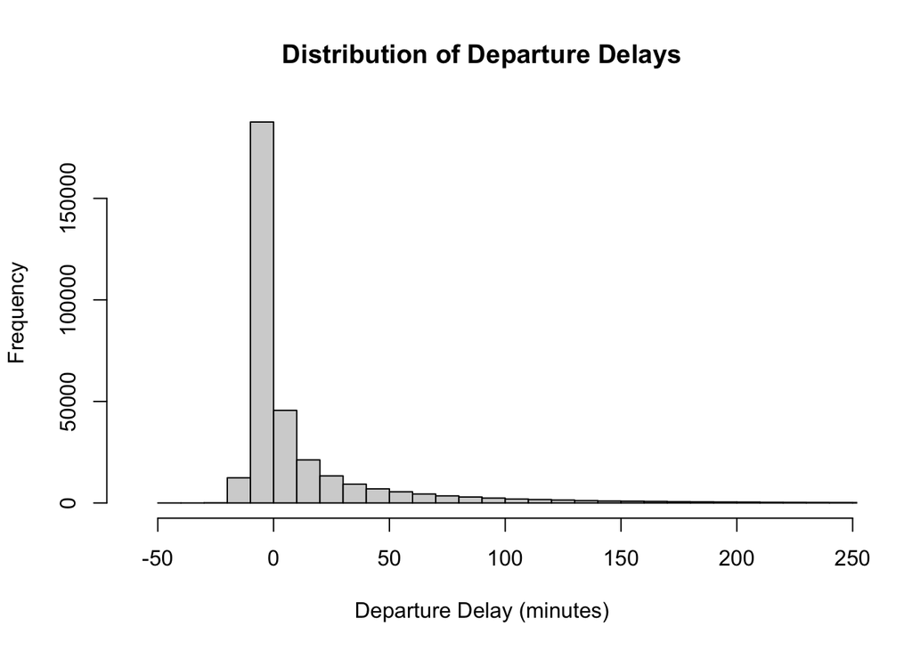

```r
# EDA Step 5: Visualize the distributions of key variables
# Histogram of Departure Delays
hist(flights_weather$dep_delay,
     main = "Distribution of Departure Delays",
     xlab = "Departure Delay (minutes)",
     breaks = 100,
     xlim = c(-60, 240))
```

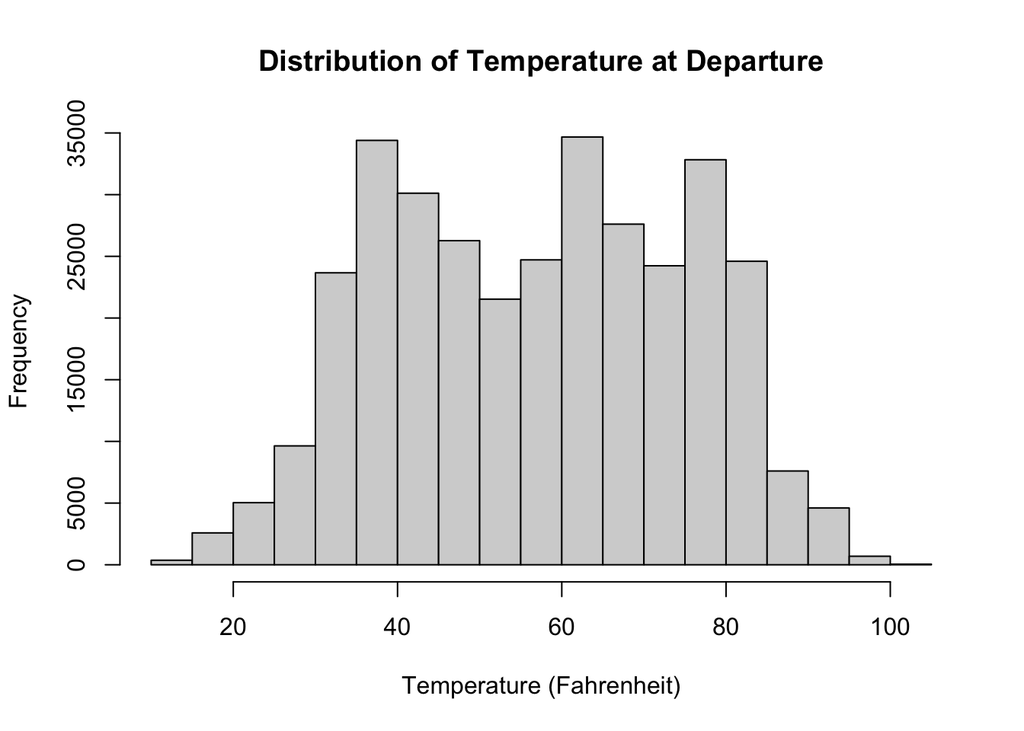

```r
# Histogram of Temperature
hist(flights_weather$temp,
     main = "Distribution of Temperature at Departure",
     xlab = "Temperature (Fahrenheit)")
```

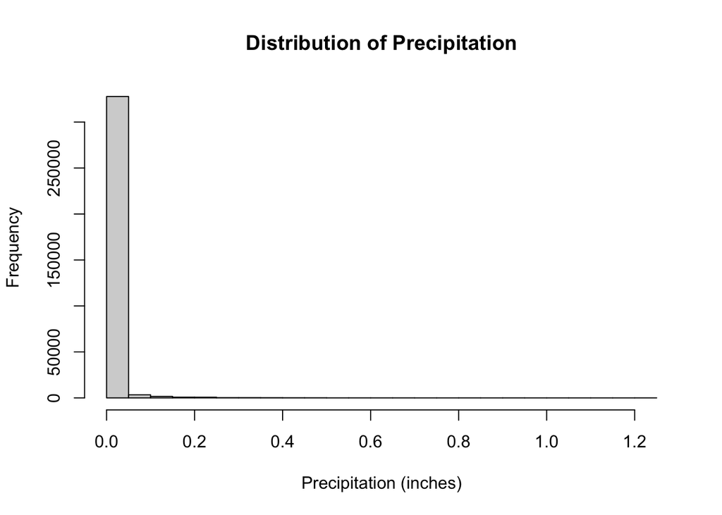

```r
# Histogram of Precipitation
hist(flights_weather$precip,
     main = "Distribution of Precipitation",
     xlab = "Precipitation (inches)")
```

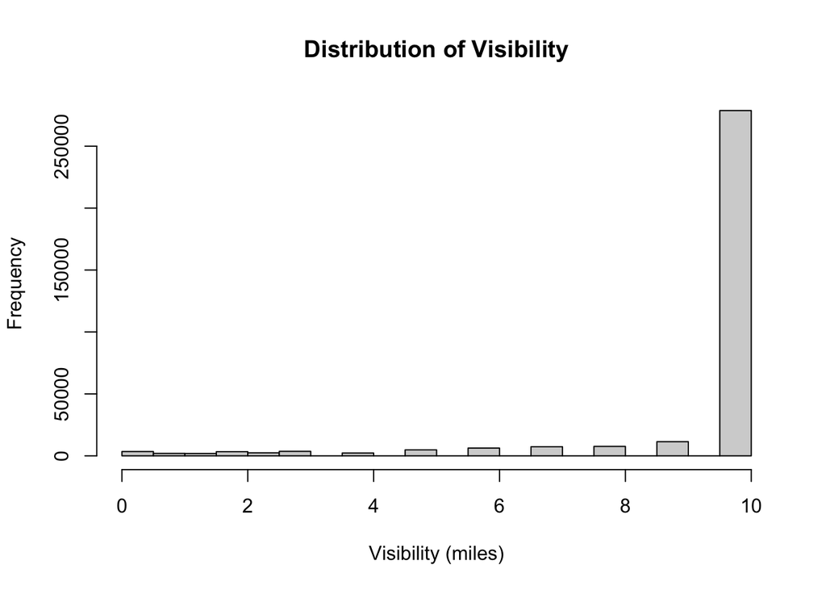

```r
# Histogram of Visibility
hist(flights_weather$visib,
     main = "Distribution of Visibility",
     xlab = "Visibility (miles)")
```

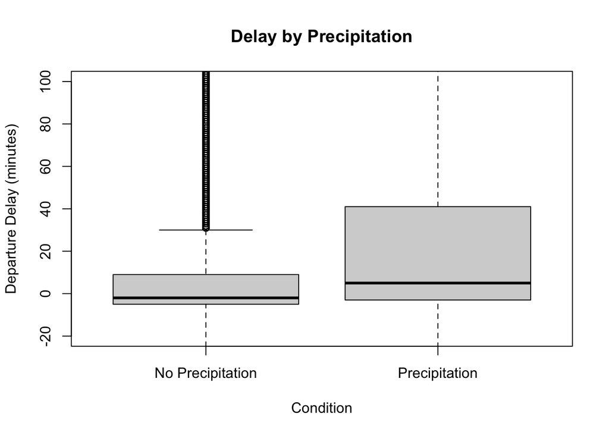

```r
# relationships between departure delay and weather variables.
# Boxplot
boxplot(dep_delay ~ ifelse(precip > 0, "Precipitation", "No Precipitation"),
        data = flights_weather,
        main = "Delay by Precipitation",
        xlab = "Condition",
        ylab = "Departure Delay (minutes)",
        ylim = c(-20, 100))
```

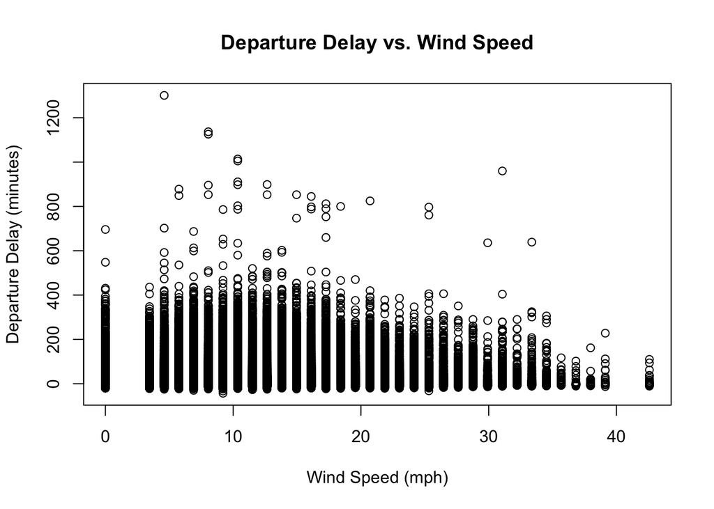

```r
# Scatterplot
plot(x = flights_weather$wind_speed, y = flights_weather$dep_delay,
     main = "Departure Delay vs. Wind Speed",
     xlab = "Wind Speed (mph)",
     ylab = "Departure Delay (minutes)")
```

The boxplot comparing delays with and without precipitation shows a clear pattern. The median delay is noticeably higher during precipitation, which strongly suggests that rain is associated with increased flight delays.

The scatterplot of departure delay versus wind speed shows a large amount of overplotting, which makes it difficult to see a clear trend in the raw data. However, it does show that long delays can occur at a wide range of wind speeds.

### Question 7

```r
# average delay per day
daily_delays <- flights_weather %>%
  group_by(month.x, day.x) %>%
  summarise(avg_delay = mean(dep_delay, na.rm = TRUE)) %>%
  arrange(desc(avg_delay))
# day with the worst delay
print(head(daily_delays, 1))
```

```
# A tibble: 1 × 3
# Groups:   month.x [1]
  month.x day.x avg_delay
    <int> <int>     <dbl>
1       3     8      83.5
```

The day with the worst average departure delay across all NYC airports was March 8th with an average delay of 83.5 minutes.

```r
daily_origin_delays <- flights_weather %>%
  group_by(origin, month.x, day.x) %>%
  summarise(avg_delay = mean(dep_delay, na.rm = TRUE)) %>%
  arrange(desc(avg_delay))
# worst airport on a single day
print(head(daily_origin_delays, 1))
```

```
# A tibble: 1 × 4
# Groups:   origin, month.x [1]
  origin month.x day.x avg_delay
  <chr>    <int> <int>     <dbl>
1 LGA          3     8      106.
```

The airport that had the worst single day for delays was LGA on March 8th with an average departure delay of 105.7 minutes.

```r
# Worst Single Hour for an Airport
hourly_origin_delays <- flights_weather %>%
  group_by(origin, time_hour) %>%
  summarise(avg_delay = mean(dep_delay, na.rm = TRUE)) %>%
  arrange(desc(avg_delay))
print(head(hourly_origin_delays, 1))
```

```
# A tibble: 1 × 3
# Groups:   origin [1]
  origin time_hour           avg_delay
  <chr>  <dttm>                  <dbl>
1 LGA    2013-07-28 21:00:00      280.
```

The worst single hour for delays was at LGA on July 28th, during the 9PM hour (21:00), where flights scheduled to leave at that time had an average delay of 279.67 minutes.

### Question 8

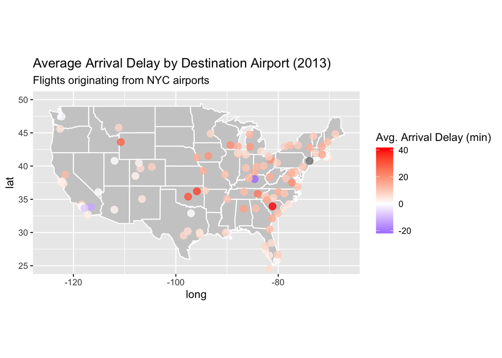

```r
# Mapping Delays by Destination

# average arrival delay for each destination
avg_delay_by_dest <- flights %>%
  group_by(dest) %>%
  summarise(avg_arr_delay = mean(arr_delay, na.rm = TRUE))
airports_with_delays <- airports %>%
  inner_join(avg_delay_by_dest, by = c("faa" = "dest"))
states <- map_data("state")
ggplot() +
  geom_polygon(data = states, aes(x = long, y = lat, group = group),
               fill = "gray80", color = "white") +
  # Add the airport points on top
  geom_point(data = airports_with_delays,
             aes(x = lon, y = lat, color = avg_arr_delay),
             alpha = 0.8, size = 3) +
  coord_fixed(1.3, xlim = c(-125, -67), ylim = c(25, 50)) +
  # color scale (blue = early, white = on-time, red = late)
  scale_color_gradient2(low = "blue", mid = "white", high = "red",
                        midpoint = 0, name = "Avg. Arrival Delay (min)") +
  labs(title = "Average Arrival Delay by Destination Airport (2013)",
       subtitle = "Flights originating from NYC airports")
```

There appears to be a concentration of destinations with higher average arrival delays in the central, southeastern, and northeastern parts of the country. In contrast, destinations on the West Coast seem to have lower (or even negative (because of flight arrived early)) average delays.

### Question 9

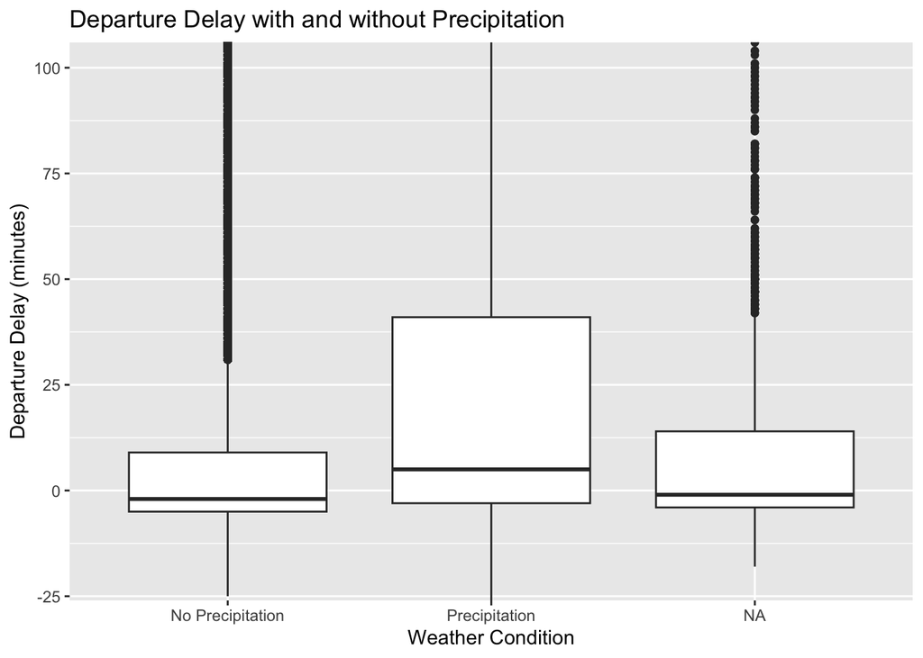

```r
# Plot 1 & Summary 1: The impact of precipitation
ggplot(data = flights_weather, aes(x = ifelse(precip > 0, "Precipitation", "No Precipitation"), y = dep_delay)) +
  geom_boxplot() +
  coord_cartesian(ylim = c(-20, 100)) +
  labs(title = "Departure Delay with and without Precipitation",
       x = "Weather Condition", y = "Departure Delay (minutes)")
```

```r
#Summary 1
flights_weather %>%
  filter(!is.na(dep_delay)) %>%
  group_by(rain_status = ifelse(precip > 0, "Precipitation", "No Precipitation")) %>%
  summarise(
    avg_delay = mean(dep_delay),
    median_delay = median(dep_delay)
  )
```

```
# A tibble: 3 × 3
  rain_status      avg_delay median_delay
  <chr>                <dbl>        <dbl>
1 No Precipitation      11.4           -2
2 Precipitation         30.9            5
3 <NA>                  13.4           -1
```

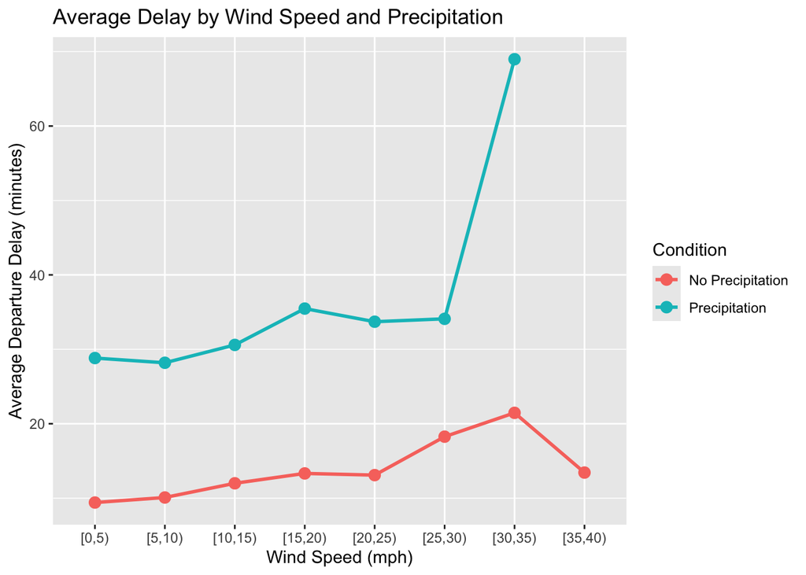

```r
# Plot 2: The combined effect of wind and precipitation
flights_weather %>%
  filter(!is.na(dep_delay) & wind_speed < 40) %>% # Filter extreme wind for a clearer plot
  mutate(
    wind_bin = cut(wind_speed, breaks = seq(0, 40, by = 5), right = FALSE),
    rain_status = ifelse(precip > 0, "Precipitation", "No Precipitation")
  ) %>%
  filter(!is.na(wind_bin)) %>%
  group_by(wind_bin, rain_status) %>%
  summarise(avg_delay = mean(dep_delay), .groups = 'drop') %>%
  ggplot(aes(x = wind_bin, y = avg_delay, color = rain_status, group = rain_status)) +
  geom_line(size = 1) +
  geom_point(size = 3) +
  labs(title = "Average Delay by Wind Speed and Precipitation",
       x = "Wind Speed (mph)", y = "Average Departure Delay (minutes)",
       color = "Condition")
```